# Part II - Interesting Interactions in the Ford GoBike Dataset

## Summary of Key Insights

- Most of the trips were fairly short in duration (about 11 minutes long), but a small proportion of trips were quite long.
- Some factors correlated quite strongly with longer trip durations, or higher average durations. These include...
  - User age/age group
  - Time of the day during which the trip started
  - Route of trip. A route means the start station and end station pair.
  - A few other factors such as the user type (Member/Subscriber) had a slight but noticeable correlation.
- There were two hours for each day during which the number of trips taken increased. These times were 8AM and 5PM respectively.
  - However that trend did not extend to weekends (Saturdays and Sundays).
- Many users seemed to prefer taking trips on Tuesdays and Thursdays compared to other days.
- There was some noticeable variation in the frequency of 'routes' taken. A 'route' means the start station and end station pair.

## Investigation Overview

- For this presentation, I'll focus mostly on how the trip duration (average or actual minute count) relates with some of the other variables.
  - These will include the user age, user type (Subscriber or Customer), the start time for the trip, the weekday and also 'routes' (i.e. start-station/end-station pair).
- Next, I will count the number of trips started or ended for each hour. I'll also explain the significance of the fact that the frequency distribution of trips for start hours is nearly the same as that for the end hours.
- The above will lead into an exploration of the distribution of trips for each weekday.
- To close things off, I will explore the counts for the most frequented 'routes'.

## Dataset Overview

This data set includes information about over 150,000 individual rides made in a bike-sharing system covering the greater San Francisco Bay area within the month of February, 2019. It includes information about where the trip started, where it ended, and how long it lasted. It also includes basic information about the customers such as their age and gender.

```python
# import all packages and set plots to be embedded inline
import numpy as np
import pandas as pd
import matplotlib.pyplot as plt
import seaborn as sb

%matplotlib inline

# suppress warnings from final output
import warnings
warnings.simplefilter("ignore")
```

```python
# load in the dataset into a pandas dataframe
df_ford = pd.read_csv('fordgobike-clean.csv')
```

```python
# some more wrangling
# convert columns to datetime
columns = ['start_time','end_time']
for col in columns:
    df_ford[col] = pd.to_datetime(df_ford[col])

# some further wrangling
# to bin the ages into groups of ten items each.
# set right=False.
age_group_bins = [a for a in range(18, 10+df_ford['user_age'].max(), 10)]

# initialise with left endpoints, then append right endpoints
age_group_labels = [f'{a}' for a in age_group_bins[0:-1]]
b = [f'{a}' for a in age_group_bins[1:]] # selects the right endpoints
for i in range(len(age_group_labels)):
    age_group_labels[i] += f'-{int(b[i])-1}'

# creating the age-group column
df_ford['age_group'] = pd.cut(x=df_ford['user_age'], bins=age_group_bins, labels=age_group_labels,
                              right=False)
```

```python
# more wrangling to make a start hour column
# for getting the hour of the time
def get_hours(column):
    return np.array(df_ford[column].dt.hour)

# we'll need this specific column later
df_ford['start_hour'] = get_hours('start_time')

# more wrangling
# creating a part of day column
# dont forget to set right=False to get [a.b) instead of (a,b]
dpart_bins = [0]+[i for i in range(6,27,3)]
#print(dpart_bins)
dpart_labels = ('Midnight-to-Dusk','Early Morning',
                'Late Morning','Early Afternoon',
                'Late Afternoon','Early Evening','Late Evening')
#print(dpart_labels)

# finally create the column 'part_of_day'
df_ford['part_of_day'] = pd.cut(df_ford['start_hour'], bins=dpart_bins,
                               labels=dpart_labels, right=False)

# make this categorical so the order is automatically respected.
weekday_order = ('Monday','Tuesday','Wednesday','Thursday','Friday','Saturday','Sunday')
df_ford['weekday'] = pd.Categorical(df_ford['weekday'],categories=weekday_order, ordered=True)
```

```python
# useful functions and constants
# defining some useful colors
rich_orange = (0.9, 0.5, 0.1)
grayish_blue = (0.3,0.4,0.5)
grayish_gray = (0.46,0.47,0.46)

# function for quick histograms
def sketch_hist(column,stepsize,custom_x=False,color='orange',data=df_ford):
    if custom_x:
        # expects column to be a numpy array
        x = column
        lowest = np.min(column) # or amin
        largest = np.max(column)
    elif not custom_x:
        x = data[column]
        lowest = data[column].min()
        largest = data[column].max()
    bins = np.arange(lowest,largest+stepsize,stepsize)
    plt.hist(x=x, bins=bins, color=color)

# more useful functions
# for plotting the labels.
def put_labels(title, x_label, y_label):
    plt.title(title)
    plt.xlabel(x_label)
    plt.ylabel(y_label)

# for conveniently placing custom tick labels
def place_ticks(least, most, step, offset=0, tick_labels=[], axis='x'):
    tick_placement = np.arange(least+offset,
                      most+step+offset,
                      step)
    tick_labels = np.array([i for i in range(least, most+step, step)]) # modfified this
    if axis=='x':
        plt.xticks(tick_placement, tick_labels)
    elif axis=='y':
        plt.yticks(tick_placement, tick_labels)

# to change the labels of the x and y axes
def label_size(n):
    axes = plt.gca()
    axes.title.set_size(n)
    axes.xaxis.label.set_size(n)
    axes.yaxis.label.set_size(n)
```

> Note that the above cells have been set as "Skip"-type slides. That means that when the notebook is rendered as http slides, those cells won't show up.

## Part 1 - Interactions regarding trip duration

What factors had a noticeable correlation with trip duration?

### 1A - Distribution of trip durations (linear plot)

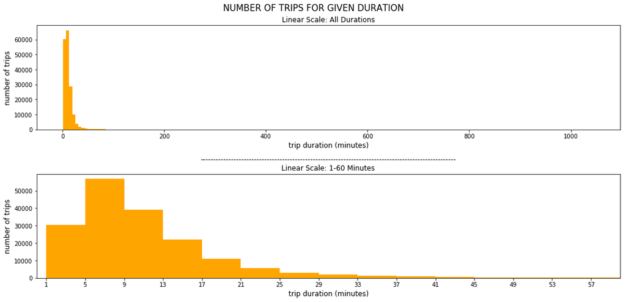

```python
# composite linear scale
duration = df_ford['duration_min']
step = 4

plt.figure(figsize=[15,7]) ;

plt.subplot(2,1,1)
put_labels('linear scale: all durations'.title(),
           'trip duration (minutes)', 'number of trips')
sketch_hist('duration_min', stepsize=6)
label_size(12)

# the linear scale x-limited
plt.subplot(2,1,2)
put_labels(100*'-'+'\nlinear scale: 1-60 minutes'.title(),
           'trip duration (minutes)', 'number of trips')
sketch_hist('duration_min', stepsize=step)
label_size(12)
place_ticks(duration.min(), duration.max(), step)
plt.xlim([0,60]) ;

plt.suptitle('NUMBER OF TRIPS FOR GIVEN DURATION', size=15, y=1.02)
plt.tight_layout()

#plt.show()
```

### Distribution of trip durations (logarithmic plot)

If we scale the x-axis logarithmically, the unimodality of the trip durations becomes clearer. The data is heavily right-skewed with most of the observations clustered around 5-10 minutes.

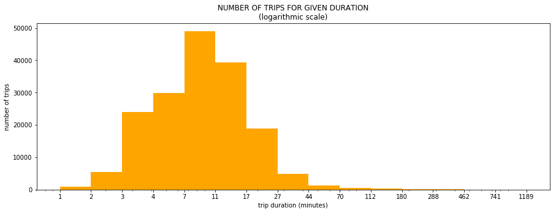

```python
# the logarithmic scale
log_step = 3
log_binsize = 0.205
log_bins = 10**np.arange(0,np.log10(duration.max())+log_binsize, log_binsize)

plt.figure(figsize=[15,5])
put_labels('NUMBER OF TRIPS FOR GIVEN DURATION\n(logarithmic scale)',
           'trip duration (minutes)', 'number of trips')
plt.xscale('log')
plt.hist(data=df_ford, x='duration_min', bins=log_bins, color='orange')
plt.xticks(log_bins, ['{n:.0f}'.format(n=x) for x in log_bins])
plt.show()
```

### 1B - Trip duration and User Age

Let's observe how the user age relates to the trip duration in minutes. The density of points in the scatterplot shows that many of the trips with the longest durations are due to younger users, as the faint lines help us to see.

The top left of each quadrant highlights the observation.

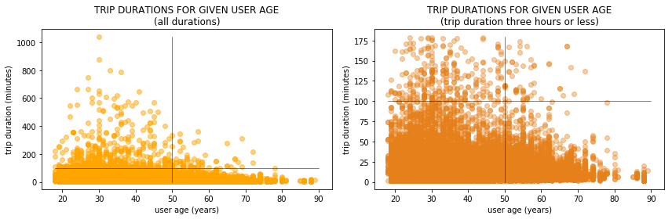

```python
# scatterplot for trip duration
plt.figure(figsize=[12,4])

plt.subplot(1,2,1)
put_labels('TRIP DURATIONS FOR GIVEN USER AGE\n(all durations)','user age (years)', 'trip duration (minutes)')
plt.scatter(data=df_ford, x='user_age', y='duration_min', alpha=0.5, color='orange') ;
# these lines are just visual guides
plt.plot([18,90],[100,100],linewidth=0.5,color='black') ;
plt.plot([50,50],[0,duration.max()],linewidth=0.5,color='black') ;

plt.subplot(1,2,2)
put_labels('TRIP DURATIONS FOR GIVEN USER AGE\n(trip duration three hours or less)',
           'user age (years)', 'trip duration (minutes)')
plt.scatter(data=df_ford[df_ford['duration_min']<=180],
            x='user_age', y='duration_min', alpha=0.4, color=rich_orange)
# these lines are just visual guides
plt.plot([18,90],[100,100],linewidth=0.5,color='black') ;
plt.plot([50,50],[0,180],linewidth=0.5,color='black') ;

plt.tight_layout()
plt.show()
```

Plotting a bar chart of average trip duration for each user age shows that the group of 18 year olds has the highest average trip duration. But when we group the users into age groups we see that the older users have higher average trip durations.

Perhaps this is due to the fact that the older users were far fewer in number, and also had many outliers i.e. users with very long durations.

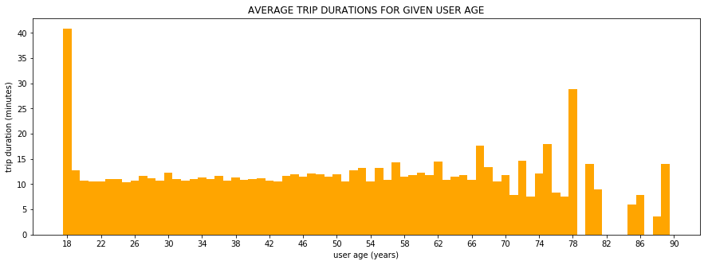

```python
# average trip duration per member age - create the data we need
grouped_age = df_ford.groupby('user_age')
grouped_age_avgdur = grouped_age['duration_min'].mean()
# plotting the average trip duration for given user age
plt.figure(figsize=[15,5])
put_labels('AVERAGE TRIP DURATIONS FOR GIVEN USER AGE',
          'user age (years)', 'trip duration (minutes)')
plt.bar(grouped_age_avgdur.index, grouped_age_avgdur.values, color='orange', width=1) ;
place_ticks(least=grouped_age_avgdur.index[0], most=grouped_age_avgdur.index[-1],
           step=4)
```

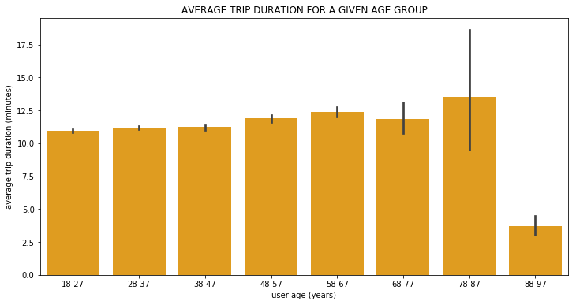

```python
# average trip duration per age group- plot the plot.
plt.figure(figsize=[12,6])
sb.barplot(data=df_ford, x='age_group', y='duration_min', color='orange')
put_labels('AVERAGE TRIP DURATION FOR A GIVEN AGE GROUP',
          'user age (years)', 'average trip duration (minutes)')
plt.show()
```

### 1C - Trip duration and User Type

Did the Subscribers have a higher average trip duration that the Customers? Was it the opposite, or were both groups nearly balanced? As we'll see in the following box plots, the median trip duration for Subscribers is consistently less than the median for Customers. This means that a majority (50 percent) of Subscribers had shorter trip durations than a majority (50 percent) of Customers.

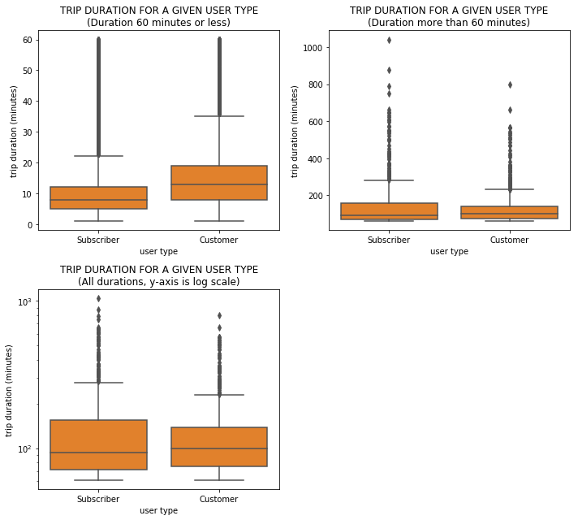

```python
# the boxplot - user type and avg trip duration
colors = sb.color_palette()
df_timelimited = df_ford[df_ford['duration_min']<=60]
df_time_excess = df_ford[df_ford['duration_min']>60]

plt.figure(figsize=[10,9])
plt.subplot(2,2,1)
sb.boxplot(data=df_timelimited,
              x='user_type', y='duration_min', color=colors[1]) ;
put_labels('TRIP DURATION FOR A GIVEN USER TYPE\n(Duration 60 minutes or less)',
          'user type', 'trip duration (minutes)')

plt.subplot(2,2,2)
sb.boxplot(data=df_time_excess,
              x='user_type', y='duration_min', color=colors[1]) ;
put_labels('TRIP DURATION FOR A GIVEN USER TYPE\n(Duration more than 60 minutes)',
          'user type', 'trip duration (minutes)')

# log scale of overall dataframe
plt.subplot(2,2,3)
plt.yscale('log')
sb.boxplot(data=df_time_excess, x='user_type', y='duration_min', color=colors[1]) ;
put_labels('TRIP DURATION FOR A GIVEN USER TYPE\n(All durations, y-axis is log scale)',
          'user type', 'trip duration (minutes)')

plt.tight_layout()
```

While it's tempting to explain this as being due to differences in pricing, the [pricing plans](https://en.wikipedia.org/wiki/Bay_Wheels#Pricing) (\$25 monthly for Subscribers, \\$3 or \$10 per trip for Customers), the pricing plans aren't that easy to compare. If a user is going to use the service only once, there's no reason for them to pay \\$25 for a month.

### 1D - Trip duration and Start time

Let's see how the start time for each trip relates to the average duration. We'll be treating start times categorically but ordinally (i.e. in an ordered fashion) as parts of the day.

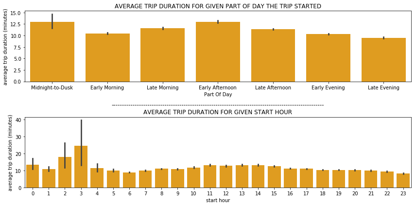

```python
# a plot showing average trip duration for time started
plt.figure(figsize=[12,6])

plt.subplot(2,1,1)
sb.barplot(data=df_ford, x='part_of_day', y='duration_min', color='orange') ;
put_labels('AVERAGE TRIP DURATION FOR GIVEN PART OF DAY THE TRIP STARTED',
          'part of day'.title(), 'average trip duration (minutes)')

# more detail
plt.subplot(2,1,2)
sb.barplot(data=df_ford, x='start_hour', y='duration_min', color='orange')
put_labels(100*'-'+'\nAVERAGE TRIP DURATION FOR GIVEN START HOUR',
          'start hour', 'average trip duration (minutes)')

plt.tight_layout()
plt.show()
```

Both plots tell us that the mean (average) trip duration spikes up around Midnight-to-Dusk (i.e. 12AM to before 6AM). The second one shows that trips started specifically between 3AM to 4AM have the longest average.

One possible explanation for why these nightly trips have such long average durations, is that some users started the trips and were unable to find start stations to end their trips before morning. It's also possible that they were too tired to end their trips, or that they were up all night. There isn't enough data in the dataset to make such specific conclusions, but those are interesting hypotheses.

Apart from those, notice that the Early Afternoon period (12PM to before 3PM) has right about the same average trip duration as Midnight-to-Dusk, but with more consistency (judging from the length of the error bar).

### 1E - Trip duration and Weekday

What days of the week account for the longest trip durations?

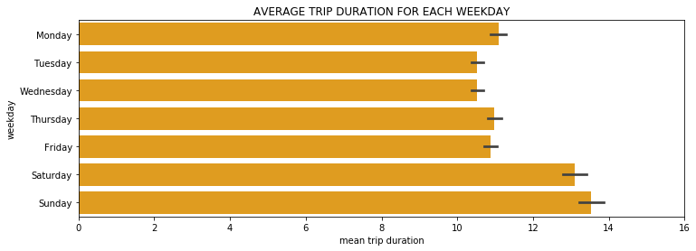

```python
# weekday
# barplot
plt.figure(figsize=[12,4])
put_labels('AVERAGE TRIP DURATION FOR EACH WEEKDAY',
          'trip duration','weekday')
sb.barplot(data=df_ford, x='duration_min', y='weekday', color='orange')
plt.xlabel('mean trip duration')
place_ticks(least=0,most=16,step=2)
```

Saturdays and Sundays account for the longest average trip durations. If we put two and two together, we can conclude that, on average, the longest trips...

- Started anywhere between Midnight and 6AM
  - Or started around Early Afternoon, which is 12PM to 3PM
- Were taken by either the youngest or oldest users
- Started on Saturdays or Sundays

Because those demographics aren't necesarily associated with a regular work schedule, we could hypothesize that most of the longest trips were recreational in nature.

## Part 2 - Most users seemed to prefer taking trips on Tuesdays and Thursdays

It's something we'll observe both from the overall counts and from comparing other variables against weekday. I can't think of any good explanation for it, and there doesn't seem like there's anything in the dataset which can put this trend in a new light.

One simple explanation is that more start stations opened up on Tuesdays and Thursdays during the month the data was recorded.

### 2A - The total number of trips counted for each weekday shows a bimodal distribution

Tuesday and Thursday recorded the highest number of trips for any given day.

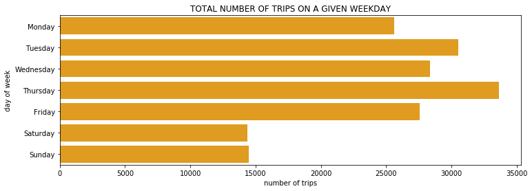

```python
# total number of trips for each weekday
plt.figure(figsize=[12,4])
sb.countplot(data=df_ford, y='weekday', color='orange') ;
put_labels('TOTAL NUMBER OF TRIPS ON A GIVEN WEEKDAY',
           'number of trips', 'day of week') ;
plt.show()
```

The following slide clearly shows that all the age groups below 58 seemed to prefer taking trips on Tuesdays and Thursdays. We'll follow that plot with a more detailed view for the older age groups.

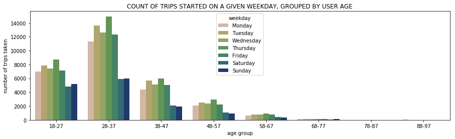

```python
# Age and weekday
# for a given age group, what day boasts the highest counts of trips taken?
plt.figure(figsize=[15,4]) ;
sb.countplot(data=df_ford, x='age_group', hue='weekday', palette='gist_earth_r') ;
put_labels('COUNT OF TRIPS STARTED ON A GIVEN WEEKDAY, GROUPED BY USER AGE',
          'age group', 'number of trips taken')
```

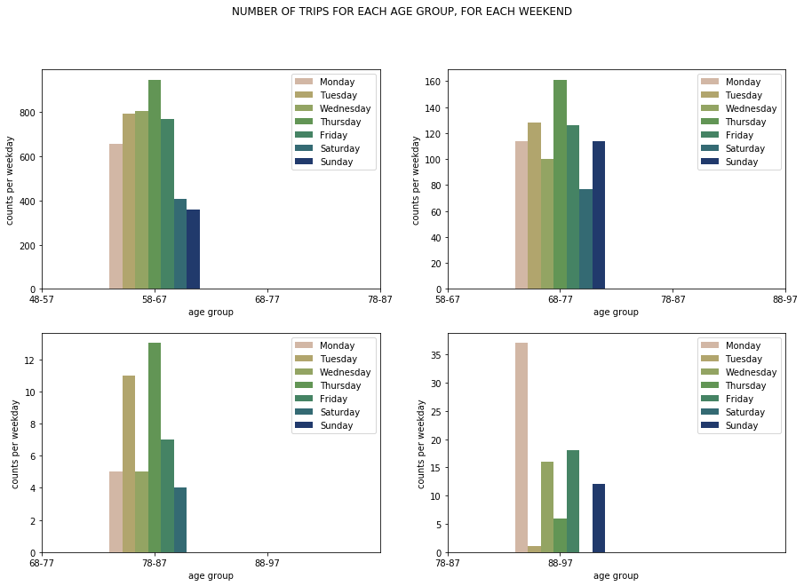

```python
# plotting the rest manually
rows, columns = 2,2
count = 1
short_agebars = ('58-67','68-77','78-87','88-97')
viewlimit = 3

plt.suptitle('NUMBER OF TRIPS FOR EACH AGE GROUP, FOR EACH WEEKEND')
for i in range(1,rows*columns+1):
    plt.subplot(2,2,i).figure.set_size_inches(15,10)
    subframe = df_ford[df_ford['age_group']==short_agebars[i-1]]
    #print(subframe.age_group.unique()) for debugging
    ax = sb.countplot(data=subframe, x='age_group', hue='weekday', palette='gist_earth_r') ;
    ax.set(xlabel='age group', ylabel='counts per weekday', xlim=[viewlimit,viewlimit+3])
    viewlimit += 1
    plt.legend(loc='upper right')

plt.show()
```

The graphics show that for the most part, most users preferred taking trips on Tuesdays and Thursdays. Now, let's move on to the next set of interactions.

## Part 3 - Interactions with respect to Start time

We'll treat start time mostly as an ordered categorical variable. We'll only consider the hour in which the trip began.

### 3A - Trip counts for each start hour

The number of trips started at any given hour peaked twice during the day. This is the trend for the dataset overall.

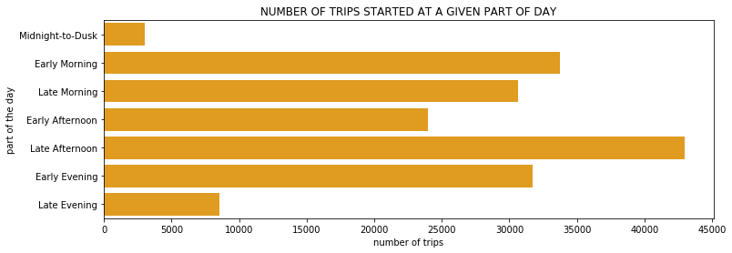

```python
# start times as categorical
daypart_counts = df_ford['part_of_day'].value_counts(ascending=True)

plt.figure(figsize=[12,4])
sb.countplot(y=df_ford['part_of_day'], color='orange') ;
plt.title('NUMBER OF TRIPS STARTED AT A GIVEN PART OF DAY')
plt.xlabel('number of trips') ;
plt.ylabel('part of the day') ;
place_ticks(least=0, most=daypart_counts.values[-1], step=5000)
```

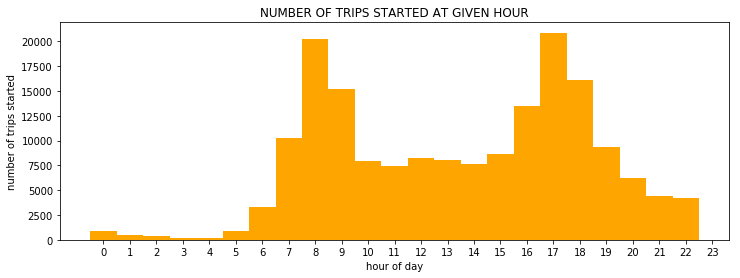

```python
# basic plot
plt.figure(figsize=(12,4))
put_labels('NUMBER OF TRIPS STARTED AT GIVEN HOUR',
           'hour of day', 'number of trips started')
# the 24 tick isn't shown because it's shifted to the right

place_ticks(least=0, most=24, step=1, offset=0.5)
sketch_hist(column='start_hour', stepsize=1) ;
```

What's just as interesting is that the number of trips ended at any given hour is nearly the same shape as the previous plot, even peaking during the same 8AM and 5PM times. We'll get to this point later.

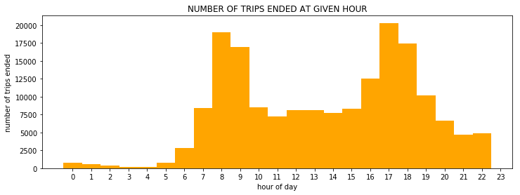

```python
# basic plot for hour at which trip ended
plt.figure(figsize=(12,4))
put_labels('NUMBER OF TRIPS ENDED AT GIVEN HOUR',
           'hour of day', 'number of trips ended')
place_ticks(least=0, most=24, step=1, offset=0.5)

sketch_hist(column=get_hours('end_time'), stepsize=1, custom_x=True)
```

### 3B - The trend seems consistent across age groups...

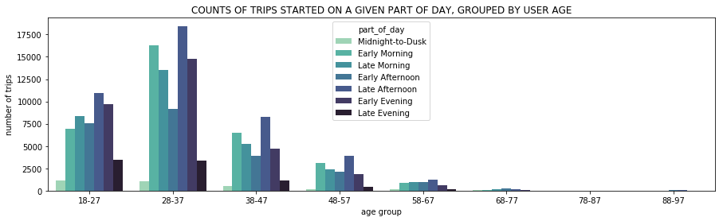

```python
# what part of the day had the highest count of trips started? Find out for each age group.
# age and part of day
plt.figure(figsize=[15,4]) ;
sb.countplot(data=df_ford, x='age_group', hue='part_of_day', palette='mako_r') ;
put_labels('COUNTS OF TRIPS STARTED ON A GIVEN PART OF DAY, GROUPED BY USER AGE',
          'age group', 'number of trips')
```

### However, there's an exception...

The users who were 58 years or older didn't show this trend. Their start times followed a more unimodal distribution, peaking at around Early to Late Afternoon. What could explain this? One hypothesis is that the younger users were heading to and returning from work (by Early Morning and Late Afternoon respectively), but the older users were going for more leisurely rides.

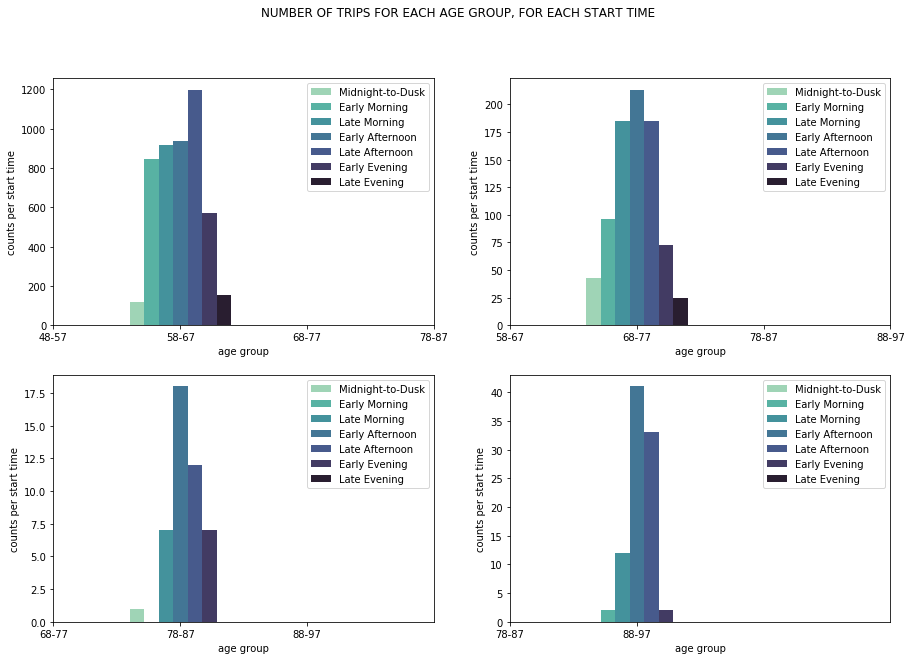

```python
# plotting the rest manually - part of day for each age group
rows, columns = 2,2
count = 1
short_agebars = ('58-67','68-77','78-87','88-97')
viewlimit = 3

plt.suptitle('NUMBER OF TRIPS FOR EACH AGE GROUP, FOR EACH START TIME')
for i in range(1,rows*columns+1):
    plt.subplot(2,2,i).figure.set_size_inches(15,10)
    subframe = df_ford[df_ford['age_group']==short_agebars[i-1]]
    #print(subframe.age_group.unique()) for debugging
    ax = sb.countplot(data=subframe, x='age_group', hue='part_of_day', palette='mako_r') ;
    ax.set(xlabel='age group', ylabel='counts per start time', xlim=[viewlimit,viewlimit+3])
    viewlimit += 1
    plt.legend(loc='upper right')

plt.show()
```

### 3C - A closer look at the relationship between Start time and End time

We noticed that the frequency distribution for the number of trips started looked very similar to that of the number of trips ended, and even had peaks at the same times of the day. Let's plot both of them side-by-side, noticing how their shapes and trends are similar except for small differences in height.

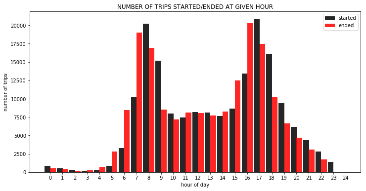

```python
# start and end time together
plt.figure(figsize=(12,6))
put_labels('NUMBER OF TRIPS STARTED/ENDED AT GIVEN HOUR',
           'hour of day', 'number of trips')
place_ticks(least=0, most=24, step=1, offset=0.45)

# we need more control so we can't use sketch_hist
bins = np.arange(0, 24+1, 1)
plt.hist(x=get_hours('start_time'), bins=bins, label='started', width=0.46, color='black', alpha=0.85) ;
plt.hist(x=get_hours('end_time'), bins=bins+0.45, label='ended', width=0.46, color='red', alpha=0.85) ;
plt.legend() ;
```

### One possible explanation for the similarity of shape

The reason for the similarity in shape is that most of the trip durations were fairly short.

It may seem obvious that the start and end hour plots should have the same shape, but that's not necessarily guaranteed. We can imagine a different Bike-sharing programme with poor logistics which somehow only has one (or a shortage of) end stations, and all those end stations open and close during a very small window for each day (say, 5PM-8PM).

All else being equal (e.g start stations being available, people starting trips as usual), the poor logistics of the end stations would force all trips to end within the same narrow window of time on any given day. In that case, the frequency distribution of the number of trips ended at a specific hour would look aggressively unimodal and peak around 5PM-8PM because no matter when the users started, they could only end their trips around that specific time of day.

However, this Bike-sharing programme doesn't seem to be like that. Most users could end their trips shortly after they started, and considering the broad geographical distribution of the Bike-sharing programme this could indicate good logistics. Still, there are small differences in height between the bars. What could explain that?

### Explaining the differences in height between the bars

Let's make a few assumptions. First, we assume that a vast majority of the users ended their trip at most one hour after they started. This is justified from the average trip duration. What this means for the visualisation is that the height of any end-of-trip bar is overwhelmingly due to...

- Users who started in the immediate previous start hour (e.g started by 10:00 AM and ended by 11:00 AM, or started by 10:50 AM and ended by 11:10 AM)
- Users who started within in the same hour (e.g. started by 10:30 AM and ended by 10:40 AM)

For a given hour, there are two possible cases, keeping in mind that the average trip duration is fairly short (about 11 minutes). Let's say it's an hour at best.

- The start bar is taller than the end bar. There are two feasible explanations for this.
  - The first explanation for this is that a number of the users started late within the current start hour and (after a short trip) ended early within the next end hour, instead of ending within same hour as the start. For example, 10:54 AM to 11:04 AM is just a ten-minute trip but it crosses an hour boundary.
  - The second is that a number of the users started early within the current hour (e.g. 10:00 AM) and after a long trip duration (say, 50 minutes) they ended within the next hour (e.g. 10:10 AM to 11:00 AM).
- The start bar is shorter than the end bar.
  - Considering the above case, the greater height of the end bar comes from people who started in the previous hour, as well as some people who started within the same hour.

If the preceding explanations are correct, the key insight is as follows - **the similarity of the distributions reinforces the fact that most of the trip durations were fairly short, and could be ended conveniently within the same hour or the next**.

### 3D - Counts of start time for each weekday

We've seen what the frequency of trips taken looked like for each start time across the entire dataset. But what if we partitioned the dataset by weekday and checked the number of trips started at any given hour, for each day of the week? What will the trend reveal?

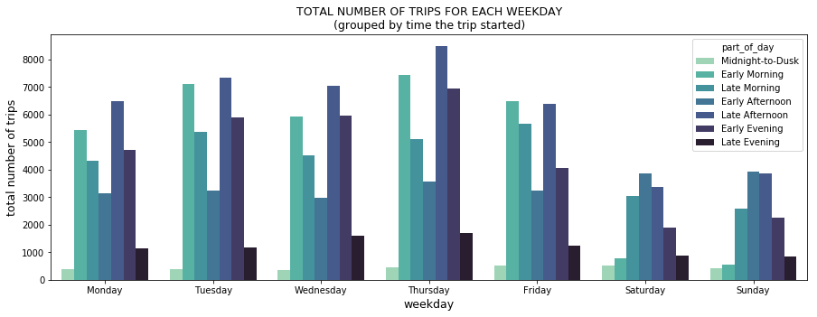

```python
# counts of start for each weekday
plt.figure(figsize=[15,5])
sb.countplot(data=df_ford, x='weekday', hue='part_of_day', palette='mako_r') ;
put_labels('TOTAL NUMBER OF TRIPS FOR EACH WEEKDAY\n(grouped by time the trip started)',
          'weekday', 'total number of trips')
label_size(12.5)
```

The bimodality disappears for Saturday and Sunday. In modern Industrialised societies (one of which is arguably San Francisco), Monday to Friday are work days and Saturday and Sunday are usually work-free days. The above distribution lends evidence to the hypothesis that the reason for the bimodal 'horns' is due to users rushing to and from work.

Let's also notice that on Saturdays and Sundays, the trip-taking rates spike around Early to Late Afternoon, which is 12PM to about 5PM. One explanation is that the users were taking leisurely trips around that time.

## Part 4 - Popular routes

To close this presentation, we'll look at interactions between start stations and end stations.

A 'route' means a start-station and end-station pair. It's meant to be a very rough estimate for the actual path traced for each bike trip. We don't have nearly enough data to actually determine the actual geographical path each user took, so all we can do is estimate using routes.

The dataset contains many start and end stations - 329 of each to be exact! If we were to consider every single route, we'd be dealing with $329*329$ routes, which is quite a lot. Instead, we'll only look at the 'popular' routes, i.e. the routes consisting of the top-ten most visited start-stations, and top-ten most visited end-stations. 'Popularity' in this sense means 'frequency'.

### 4A - The popularity of the most frequented start and end stations

We'll look at a Heatmap showing the popularity of routes made up of the most frequented start and end stations. Which routes were the most used? How often were they used?

```python
# Step 1 - filter the dataframe for the top five start stations and top five end stations
n = 10

topn_start = df_ford['start_station_name'].value_counts(ascending=False)[0:n]
topn_end = df_ford['end_station_name'].value_counts(ascending=False)[0:n]

# a reference to the original df, but filtered
df_topjourneys = df_ford[df_ford['start_station_name'].isin(topn_start.index)]
df_topjourneys = df_topjourneys[df_topjourneys['end_station_name'].isin(topn_end.index)]

# Step 2 - group
topj_counts = df_topjourneys.groupby(['start_station_name', 'end_station_name']).count()['duration_sec']
topj_counts = topj_counts.reset_index(name='end_station_counts')
#topj_counts

# Step 3 - pivot the table
topj_counts = topj_counts.pivot(index = 'start_station_name', columns = 'end_station_name',
                            values = 'end_station_counts') ;
#topj_counts
```

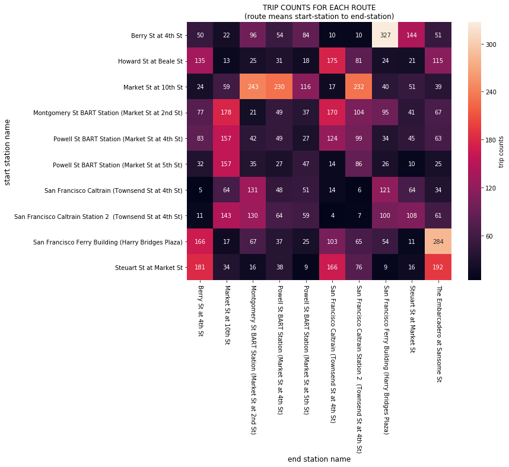

```python
# Step 4 - make a heatmap of journey counts
plt.figure(figsize=[10,8])
ax = sb.heatmap(topj_counts, annot = True, fmt = 'd', cbar_kws = {'label' : 'trip counts'}) ;
ax.set(xlabel='end station name', ylabel='start station name',
       title='TRIP COUNTS FOR EACH ROUTE\n(route means start-station to end-station)')
plt.yticks(rotation=0)
plt.xticks(rotation=-90) ;
label_size(12)
```

We can see the most popular route near the top-right. It's the brightest colour there. It started at "Berry St at 4th St" and ended at "San Francisco Ferry Building (Harry Bridges Plaza)".

327 trips may not seem like a lot given the size of the dataset, but look at the range within the same heatmap. A route like "San Francisco Caltrain Station 2 (Townsend St at 4th St)" to "San Francisco Caltrain (Townsend St at 4th St)" only had 4 trips across it.

We'd need physical geographical data to fully grasp the ramifications of this heatmap, but it's nice to know the popularity of some of the routes.

### 4B - Average trip duration for popular routes

For each of the popular routes shown previously, what's the average trip duration? Would we expect the most popular route to have the longest or the shortest trip duration?

[Much credit goes to Udacity](https://classroom.udacity.com/nanodegrees/nd002-alg-t2/parts/cd0016/modules/7e1817ca-5505-4583-b772-2e50d49a14a0/lessons/ls2237/concepts/d629b721-fc26-4f4f-a7d5-2af2d6f17bff) for inspiring the following code.

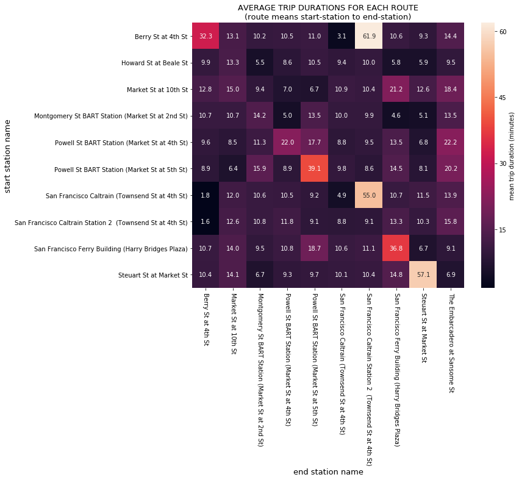

```python
# Avg trip duration for each start and end station.
plt.figure(figsize=[10,8])

cat_means = df_topjourneys.groupby(['end_station_name', 'start_station_name']).mean()['duration_min']
cat_means = cat_means.reset_index(name = 'average_trip_duration') ;
cat_means = cat_means.pivot(index = 'start_station_name', columns = 'end_station_name',
                            values = 'average_trip_duration') ;
ax = sb.heatmap(cat_means, annot = True, fmt = '.1f', cbar_kws = {'label' : 'mean trip duration (minutes)'}) ;
ax.set(xlabel='end station name', ylabel='start station name',
       title='AVERAGE TRIP DURATIONS FOR EACH ROUTE\n(route means start-station to end-station)')

label_size(13)
plt.yticks(rotation=0)
plt.xticks(rotation=-90) ;
```

The route with the longest average trip duration is the brightest colour near the top-right corner. Its name is...

- "Berry St at 4th St" to "San Francisco Caltrain Station 2 (Townsend St at 4th St)", which had an average trip duration of 61.9 minutes (slightly over an hour long).

That route has the same start station, but it's not the same as the most frequented route, which was "Berry St at 4th St" to "San Francisco Ferry Building (Harry Bridges Plaza)". In fact, it we look at the trip counts for each route (about two previous slides) we'll see that this route with the longest average trip wasn't very popular. It hosted only 10 trips, compared to the most popular's 327 trips.

## Thank you for your time.

### Generate Slideshow

Once you're ready to generate your slideshow, use the `jupyter nbconvert` command to generate the HTML slide show.

```python
# Use this command if you are running this file in local
!jupyter nbconvert Part_II_slide_deck.ipynb --to slides --post serve --no-input --no-prompt
```

[output not shown]

> In the classroom workspace, the generated HTML slideshow will be placed in the home folder.

> In local machines, the command above should open a tab in your web browser where you can scroll through your presentation. Sub-slides can be accessed by pressing 'down' when viewing its parent slide. Make sure you remove all of the quote-formatted guide notes like this one before you finish your presentation! At last, you can stop the Kernel.

### Submission

If you are using classroom workspace, you can choose from the following two ways of submission:

1. **Submit from the workspace**. Make sure you have removed the example project from the /home/workspace directory. You must submit the following files:
   - Part_I_notebook.ipynb
   - Part_I_notebook.html or pdf
   - Part_II_notebook.ipynb
   - Part_I_slides.html
   - README.md
   - dataset (optional)
1. **Submit a zip file on the last page of this project lesson**. In this case, open the Jupyter terminal and run the command below to generate a ZIP file.

   ```
   zip -r my_project.zip .
   ```

   The command abobve will ZIP every file present in your /home/workspace directory. Next, you can download the zip to your local, and follow the instructions on the last page of this project lesson.